# Biological structure tags with watershedding

```python
import os

import matplotlib.pyplot as plt
import networkx as nx
import numpy as np
import tifffile as tif

from scipy import ndimage as ndi
from skimage.morphology import dilation, square, watershed
from skimage.feature import peak_local_max
```

## Load data

Assumes the following project directory structure:

```
lcimb
|-- code
|    `-- leapmanlab
|        `-- notebooks
|            `-- watershedding.ipynb
`-- data
    `-- platelet
        |-- label-volume.tif
        `-- train-volume.tif
```

```python
# Root project directory relative to this notebook
lcimb_dir = '../../..'
# Use platelet data
data_dir = os.path.join(lcimb_dir, 'data/platelet')
```

Load a platelet image volume and its manual segmentation.

```python
image = tif.imread(os.path.join(data_dir, 'train-volume.tif'))
segmentation = tif.imread(os.path.join(data_dir, 'label-volume.tif'))
```

Choose representative 2D z-slices from the image and segmentation volumes.

```python
z_slice = 0
image2d = image[z_slice, ...]
segmentation2d = segmentation[z_slice, ...]
```

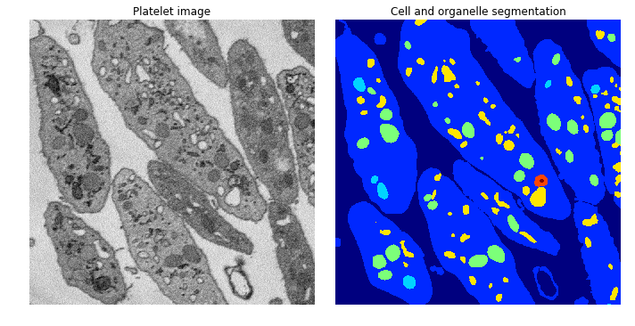

```python
# Display a sample of the image and segmentation
fig, axes = plt.subplots(ncols=2, figsize=(10, 5), sharex=True, sharey=True)
ax = axes.ravel()
ax[0].imshow(image2d, cmap='gray', interpolation='nearest')
ax[0].set_title('Platelet image')
ax[1].imshow(segmentation2d, cmap='jet', vmin=0, vmax=6,
             interpolation='nearest')
ax[1].set_title('Cell and organelle segmentation')

for a in ax:
    a.set_axis_off()
fig.tight_layout()
plt.show()
```

## Creating binary masks

The raw segmentation file assigns one of seven classes to each voxel: background, cytoplasm, and five organelle classes. For object tagging, it is also useful to use simpler binary masks that merge classes together. We define a helper function to simplify class merging.

```python
from typing import Dict

def merge_classes(image: np.ndarray, mapping: Dict[int, int]) -> np.ndarray:
    """Merge classes together in an image array.

    Input `mapping` keys correspond to array values in the input
    `image`. This function copies the input `image` and replaces array values
    with the corresponding key values in `mapping`.

    Example:
        Simple 2x2 image with three classes. Map classes 1 and 2 together as
        a new class 1.
        >>> image = np.array([[0, 1],
                              [2, 1]])
        >>> mapping = {0: 0, 1: 1, 2: 1}
        >>> merge_classes(image, mapping)
        array([0, 1],
              [1, 1])


    Args:
        image (np.ndarray): An image array, assumed to be a segmentation of
            another image data source and therefore consisting of a small
            number of values representing class labels.
        mapping (Dict[int, int]): Mapping from old class labels to new class
            labels. There must be one key for each class label in the input
            `image`. Key values are the corresponding new class labels.

    Returns:
        (np.ndarray): A new copy of the image with class labels merged
            together.
    """
    new_image = np.copy(image)
    # Iterate through the new image array. Use the more complicated
    # numpy iterable syntax to allow the new image array to be modified in
    # place
    with np.nditer(new_image, op_flags=['readwrite']) as it:
        for c in it:
            # Map the old class label to the new class label
            c[...] = mapping[int(c)]
    return new_image
```

Use the `merge_classes` function to create two new binary masks - one that merges all cellular content together into a single cell label, and one contains all organelles.

```python
cell_mapping = {0: 0, 1: 1, 2: 1, 3: 1, 4: 1, 5: 1, 6:1}
cells = merge_classes(segmentation, cell_mapping)

organelle_mapping = {0: 0, 1: 0, 2: 1, 3: 1, 4: 1, 5: 1, 6: 1}
organelles = merge_classes(segmentation, organelle_mapping)
```

Create 2D slices of the masks for display purposes.

```python
cells2d = cells[z_slice, ...]
organelles2d = organelles[z_slice, ...]
```

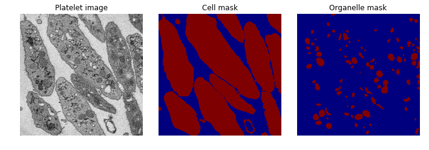

```python
# Display a sample of the image and segmentation
# Display an xy slice with this z coordinate
z_slice = 0
fig, axes = plt.subplots(ncols=3, figsize=(10, 3.33), sharex=True, sharey=True)
ax = axes.ravel()
ax[0].imshow(image2d, cmap='gray', interpolation='nearest')
ax[0].set_title('Platelet image')
ax[1].imshow(cells2d, cmap='jet', vmin=0, vmax=1,
             interpolation='nearest')
ax[1].set_title('Cell mask')
ax[2].imshow(organelles2d, cmap='jet', vmin=0, vmax=1,
             interpolation='nearest')
ax[2].set_title('Organelle mask')

for a in ax:
    a.set_axis_off()
fig.tight_layout()
plt.show()
```

## Cell tagging

A segmentation map labels each pixel, but ultimately what we want is a list of tags identifying regions in the image as separate objects. A standard tool for doing this is [distance transform watershedding](https://imagej.net/Distance_Transform_Watershed). We first demonstrate this for tagging cells.

**Distance transform**: Assume a binary mask with labels 0 and 1. For each pixel labeled 1, compute the distance to the nearest pixel labeled 0.

```python
distance2d = ndi.distance_transform_edt(cells2d)
```

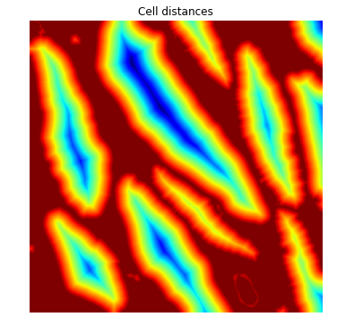

```python
fig, ax = plt.subplots(figsize=(6, 6))
ax.imshow(-distance2d, cmap='jet', interpolation='nearest')
ax.set_title('Cell distances')
ax.set_axis_off()
plt.show()
```

```python
local_maxes2d = peak_local_max(distance2d, indices=False,
                               footprint=np.ones((3,3)), labels=cells2d,
                               exclude_border=False)
local_maxes2d_xy = peak_local_max(distance2d, indices=True,
                                  footprint=np.ones((3,3)), labels=cells2d,
                                  exclude_border=False)
markers2d = ndi.label(local_maxes2d)[0]
```

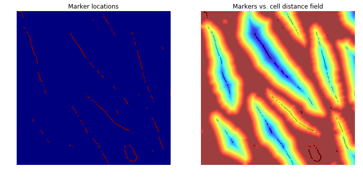

```python
# Marker points can be hard to see. Dilate them a little
dilated2d = dilation(markers2d, square(5))

fig, axes = plt.subplots(ncols=2, figsize=(12, 6))
ax = axes.ravel()
ax[0].imshow(dilated2d, cmap='jet', vmin=0, vmax=1, interpolation='nearest')
ax[0].set_title('Marker locations')
ax[1].imshow(-distance2d, cmap='jet', interpolation='nearest')
ax[1].imshow(1-dilated2d, cmap='gray', vmin=0, vmax=1, interpolation='nearest',
          alpha=0.25)
ax[1].set_title('Markers vs. cell distance field')
for a in ax:
    a.set_axis_off()
plt.show()
```

This image reveals a drawback with distance transform seeding for EM data - cell cross sections form irregular figures and the cell interiors form ridges of distance local maxima. This set of markers will not work well with basic watershedding.

```python
tags = watershed(-distance2d, markers2d, mask=cells2d)
```

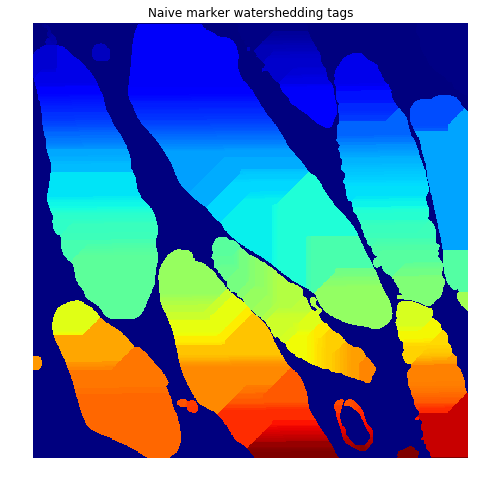

```python
fig, ax = plt.subplots(figsize=(8, 8))
ax.imshow(tags, cmap='jet', interpolation='nearest')
ax.set_title('Naive marker watershedding tags')
ax.set_axis_off()
plt.show()
```

```python
max_to_tag = np.zeros(n_maxes, dtype=np.int)
for i, m in enumerate(local_maxes2d_xy):
    max_to_tag[i] = tags[m[0], m[1]]

tag_to_marker = [[] for _ in range(tags.max() + 1)]

for j, t in enumerate(max_to_tag):
    tag_to_marker[t].append(j)
tag_to_marker[0].append(-1)
ref_markers = [t[0] for t in tag_to_marker]
print(ref_markers)
```

```
[-1, 662, 661, 660, 659, 658, 657, 656, 655, 654, 653, 652, 651, 650, 649, 648, 647, 646, 645, 644, 643, 642, 641, 640, 639, 638, 637, 636, 635, 634, 633, 632, 631, 630, 629, 628, 627, 626, 625, 624, 623, 622, 621, 620, 619, 618, 617, 616, 615, 614, 613, 612, 611, 610, 609, 608, 607, 606, 605, 604, …
```

To be clear, each cell should be a single color, meaning that the entire region in the image shares a single tag.

The name "watershedding" alludes to the metaphor for the procedure as the filling of basins with water. When object cross sections are approximately elliptical, each basin has a unique local maxima. The basins created by platelets each have many local maxima lying approximately along a line. If we could merge markers belonging to the same basin, we could use the new marker info.

**Conjecture**: There might be some math that can be done to devise a smart way to do this marker merging. Platelet cross sections are approximately convex, their distance transform level sets are approximately convex, looking at the total variation of the distance transform along lines connecting local maxima might be a useful way to tell whether markers are connected.

**Idea**: Given an $I\times J$ binary image $\mathbf{x}(i, j)$ on the domain $\Omega=\{0, \ldots, I-1\}\times\{0, \ldots, J-1\}$, let $D(p)\triangleq D(\mathbf{x})(p)$ be the Euclidean distance transform of $\mathbf{x}$, and $\mathcal{M}\subset\Omega$ the set of local maxima of $D$. For any $m,n\in\mathcal{M}$, let $L(m, n)$ be the line connecting points $m$ and $n$. Next define $\delta(m, n)= \max_{p\in L(m, n)}D(p)-\min_{p\in L(m, n)}D(p)$. $\delta(m, n)$ measures the maximum difference in value of the distance function along the line between $m$ and $n$. I conjecture that the value of $\delta$ should be small when $m$ and $n$ are in the same basin, and large when they are not.

**Problem**: $\delta$'s magnitude depends on the size of the object(s) containing $m$ and $n$. How to normalize?

```python
def delta(a, m, n):
    x0, y0 = m
    x1, y1 = n
    d = ((x1 - x0)**2 + (y1 - y0)**2)**.5
    n = int(2 * d)
    x, y = np.linspace(x0, x1, n), np.linspace(y0, y1, n)
    z = ndi.map_coordinates(a, np.vstack((x, y)))
    z_bdry_min = min(z[0], z[-1])
    diff_min = np.abs(z[0]-z[-1])
    diff_max = z.max() - z.min()
    return (diff_max - diff_min) / (z_bdry_min + 1e-6)

delta(distance2d, local_maxes2d_xy[8], local_maxes2d_xy[5])
```

```
0.0
```

```python
dist_threshold = 100

n_maxes = local_maxes2d_xy.shape[0]
adjacencies = np.zeros((n_maxes, n_maxes))
for m in range(n_maxes):
    max0 = local_maxes2d_xy[m]
    for n in range(m + 1, n_maxes):
        max1 = local_maxes2d_xy[n]
        dist = np.linalg.norm(max1 - max0)
        if dist > dist_threshold:
            adjacencies[m, n] = 1
        else:
            adjacencies[m, n] = delta(distance2d,
                                      local_maxes2d_xy[m],
                                      local_maxes2d_xy[n])
```

```python
edge_threshold = 0.1
X = [[], []]
Y = [[], []]
for m in range(n_maxes):
    p = local_maxes2d_xy[m]
    for n in range(m + 1, n_maxes):
        q = local_maxes2d_xy[n]
        a = adjacencies[m, n]
        if a < edge_threshold:
            sx = p[1]
            sy = p[0]
            tx = q[1]
            ty = q[0]
            X[0].append(sx)
            X[1].append(tx)
            Y[0].append(sy)
            Y[1].append(ty)
```

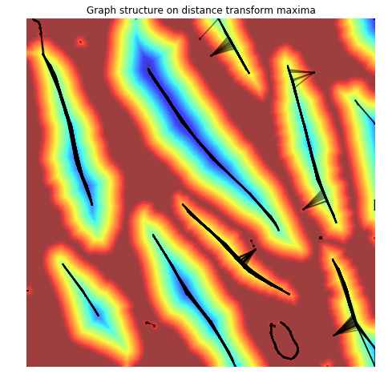

```python
fig, ax = plt.subplots(figsize=(8, 8))
ax.imshow(-distance2d, cmap='jet', interpolation='nearest')
ax.imshow(1-dilated2d, cmap='gray', vmin=0, vmax=1, interpolation='nearest',
          alpha=0.25)

ax.plot(X, Y, 'k-', alpha=0.5)

ax.set_title('Graph structure on distance transform maxima')
ax.set_axis_off()
plt.show()
```

```python
for n in range(n_maxes):
    adjacencies[n, n] = 1
adj_mat = (adjacencies + adjacencies.T < edge_threshold).astype('i1')

graph = nx.from_numpy_matrix(adj_mat)
cc = [list(c) for c in nx.connected_components(graph)]
```

```python
print(cc[4])
local_maxes2d_xy[cc[4]]
component_labels = -np.ones(n_maxes)
for i, c in enumerate(cc):
    for e in c:
        component_labels[e] = i
```

```
[128, 97, 129, 99, 134, 103, 104, 105, 136, 109, 110, 111, 112, 115, 116, 87, 90, 124, 93]
```

```python
new_tags = np.zeros((800, 800))
for y in range(800):
    for x in range(800):
        old_tag = tags[y, x]
        if old_tag == 0:
            new_tags[y, x] = 0
        else:
            old_tag_marker = ref_markers[old_tag]
            marker_component = component_labels[old_tag_marker]
            new_tags[y, x] = marker_component
```

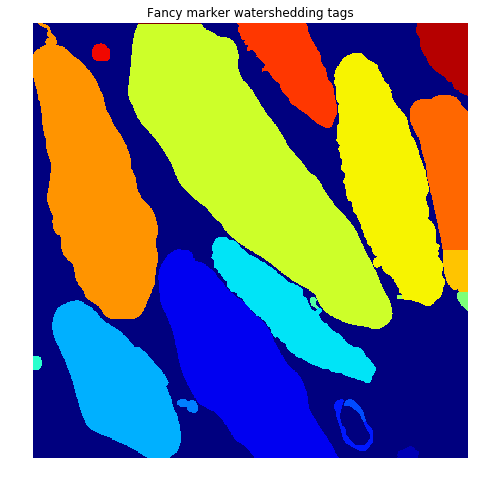

```python
fig, ax = plt.subplots(figsize=(8, 8))
ax.imshow(new_tags, cmap='jet', interpolation='nearest')
ax.set_title('Fancy marker watershedding tags')
ax.set_axis_off()
plt.show()
```